# Alluvial Plots with ggalluvial

**Biostatistician:** Victoria Cooley

*September 13, 2021*

# Introduction

## Background

- Show the flow and change in frequencies as process flows between between states (in our case, variables)
- Can visualize the relationship between many categorical variables at once, including the status variable
- Investigators love them, be are often interpreted incorrectly!
- We’ll be using the `ggalluvial` package, a ggplot2 extension for alluvial plots

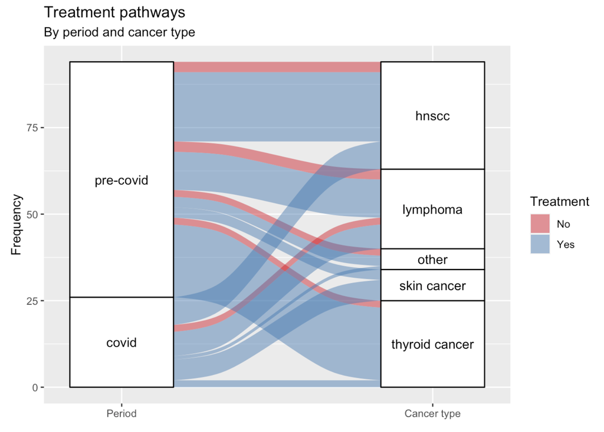

## Some vocabulary

- Axis: variable(s) from your dataset; data are grouped/stacked vertically and at certain horiztonal positions across normal x-axis (period and cancer type in the plot above)
- Strata: the groupings of each axis variable (think factor levels of categorical variable; pre-covid and covid for period)
- Alluvia: horizontal splines that are distributed across the plot; identified by vertical position on axis and fill color (treatment)
- Flows: segments of alluvial between axes
- Lodes: where the alluvia intersect the stata; cannot visualize in plots. Can imagine as rectangular box that continues from the flows through the strata

# Data types

- Three major types (wide, long, and tabular/array)
- We will focus on wide and long (like the arrangement for repeated measures data)

## Wide format

- We will use the Arthritis dataset from the `vcd` package
- Each row = grouping of observations that take certain value of each variable
- Each variable has own column
- Include an additional column the tallies the combinations of the variables
- One row per alluvium

```r
data(Arthritis)

Arthritis %>% group_by(Treatment, Sex, Improved) %>% tally()
```

| Treatment | Sex | Improved | n |
| --- | --- | --- | --- |
| Placebo | Female | None | 19 |
| Placebo | Female | Some | 7 |
| Placebo | Female | Marked | 6 |
| Placebo | Male | None | 10 |
| Placebo | Male | Marked | 1 |
| Treated | Female | None | 6 |
| Treated | Female | Some | 5 |
| Treated | Female | Marked | 16 |
| Treated | Male | None | 7 |
| Treated | Male | Some | 2 |

[output cut: 1 more lines]

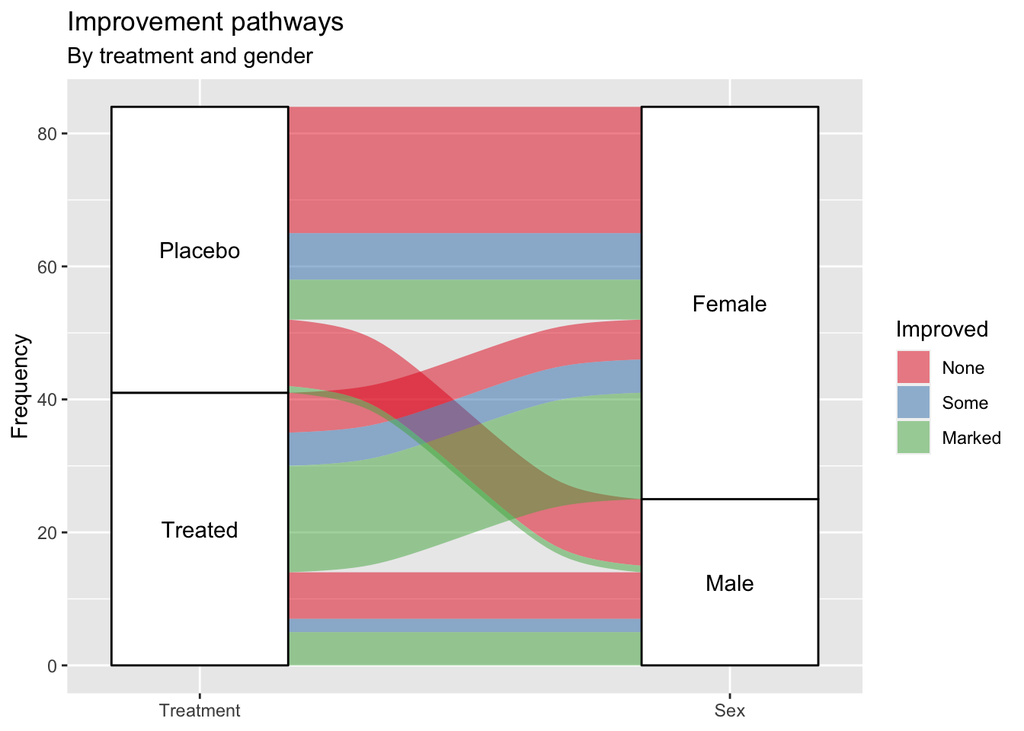

```r
Arthritis_grp <- Arthritis %>% group_by(Treatment, Sex, Improved) %>% tally()
Arthritis_grp %>%
ggplot(
  aes(y = n, axis1 = Treatment, axis2 = Sex)) +
  scale_x_discrete(limits = c("Treatment", "Sex"), expand = c(.2, .05)) +
  geom_alluvium(aes(fill = Improved)) +
  geom_stratum() +
  geom_text(stat = "stratum", aes(label = after_stat(stratum)), min.y = 5) +
  ggtitle("Improvement pathways",
          "By treatment and gender") +
  ylab("Frequency") +
  scale_fill_brewer(type = "qual", palette = "Set1")
```

- Notice how there are not any gaps or white spaces in the above plot
- Height of the plot = cumulative sum of all observations in data set

## Lodes/long format

- We can convert the above dataset into lodes (long) format using the `to_lodes_form()` function
- One row per lode
- “gathering” (dplyr) of the axis columns to create axis-stratum pairs
- Useful for repeated measures data (see additional example below)

```r
Arthritis_lodes <- to_lodes_form(as.data.frame(Arthritis_grp),
                           axes = 1:3,
                           id = "Cohort")


Arthritis_lodes
```

| n | Cohort | x | stratum |
| --- | --- | --- | --- |
| 19 | 1 | Treatment | Placebo |
| 7 | 2 | Treatment | Placebo |
| 6 | 3 | Treatment | Placebo |
| 10 | 4 | Treatment | Placebo |
| 1 | 5 | Treatment | Placebo |
| 6 | 6 | Treatment | Treated |
| 5 | 7 | Treatment | Treated |
| 16 | 8 | Treatment | Treated |
| 7 | 9 | Treatment | Treated |
| 2 | 10 | Treatment | Treated |

[output cut: 23 more lines]

```r
is_lodes_form(Arthritis_lodes, key = x, value = stratum, id = Cohort, silent = TRUE)
```

[1] TRUE

In the above transformed data we have the following:

- x: the axis variable that is plotted on the x axis
- stratum: the different levels that each axis variable can assume
- alluvium: the id assigned to each axis-stratum pair

### Vaccinations data

- Let’s look at the vaccinations data, which is a more applicable example of long format (response from one question from three surveys)

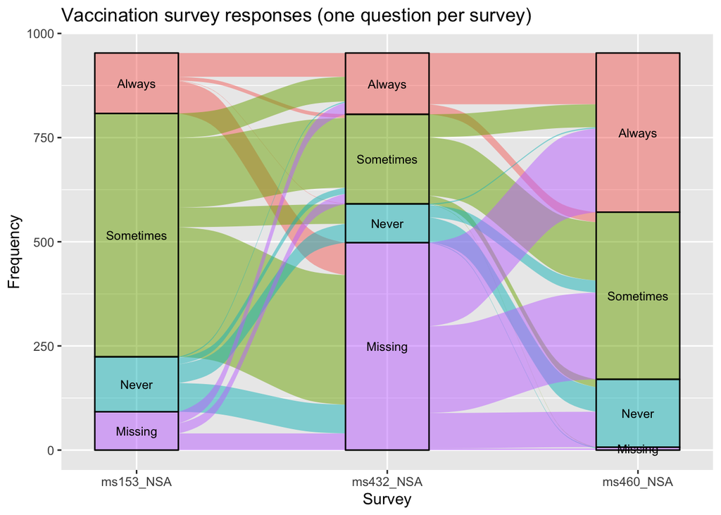

```r
data(vaccinations)

vaccinations <- vaccinations %>%
                mutate(response = forcats::fct_relevel(response, "Always", "Sometimes",
                                                       "Never", "Missing"))

ggplot(vaccinations,
       aes(x = survey, stratum = response, alluvium = subject,
           y = freq,
           fill = response, label = response)) +
  scale_x_discrete(expand = c(.1, .1)) +
  geom_flow() +
  geom_stratum(alpha = .5) +
  geom_text(stat = "stratum", size = 3) +
  theme(legend.position = "none") +
  ylab("Frequency") +
  xlab("Survey") +
  ggtitle("Vaccination survey responses (one question per survey)")
```

- Notice in the above plot there is one stratum where the text does not fit well
- To fix the latter we can set a parameter `aes(label = after_stat(stratum)), min.y = 8)` to restrict labeling to a certain vertical height

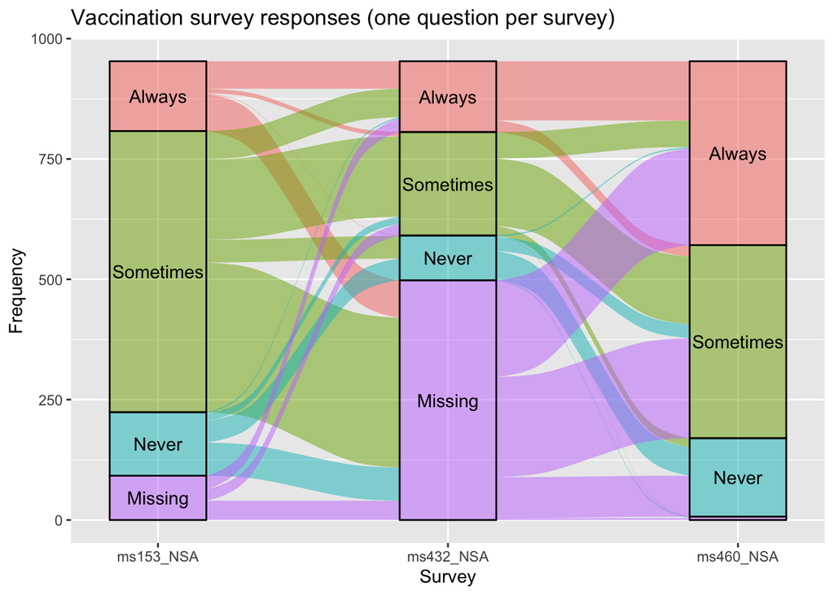

```r
ggplot(vaccinations,
       aes(x = survey, stratum = response, alluvium = subject,
           y = freq,
           fill = response, label = response)) +
  scale_x_discrete(expand = c(.1, .1)) +
  geom_flow() +
  geom_stratum(alpha = .5) +
  geom_text(stat = "stratum", aes(label = after_stat(stratum)), min.y = 8) +
  theme(legend.position = "none") +
  ylab("Frequency") +
  xlab("Survey") +
  ggtitle("Vaccination survey responses (one question per survey)")
```

**Notes**

- The geom_alluvium() differs from geom_flow() - depends on the type of dataset and the purpose of the plot!
- Regarding missing values, in the plot above the removal would result in gaps whereas in the earlier plots this would not occur (depends on type of data)

# Additional customizations

- We’ll revisit the arthritis dataset

## Curve types

- Type of curve used to produce flows
- Default: “xspline” (approximation splines using 4 points per curve)
- Other options: “linear”, “cubic”, “quintic”, “sine”, “arctangent”, and “sigmoid” (produce interpolation splines between points along the graphs of functions of the associated type)

### Linear

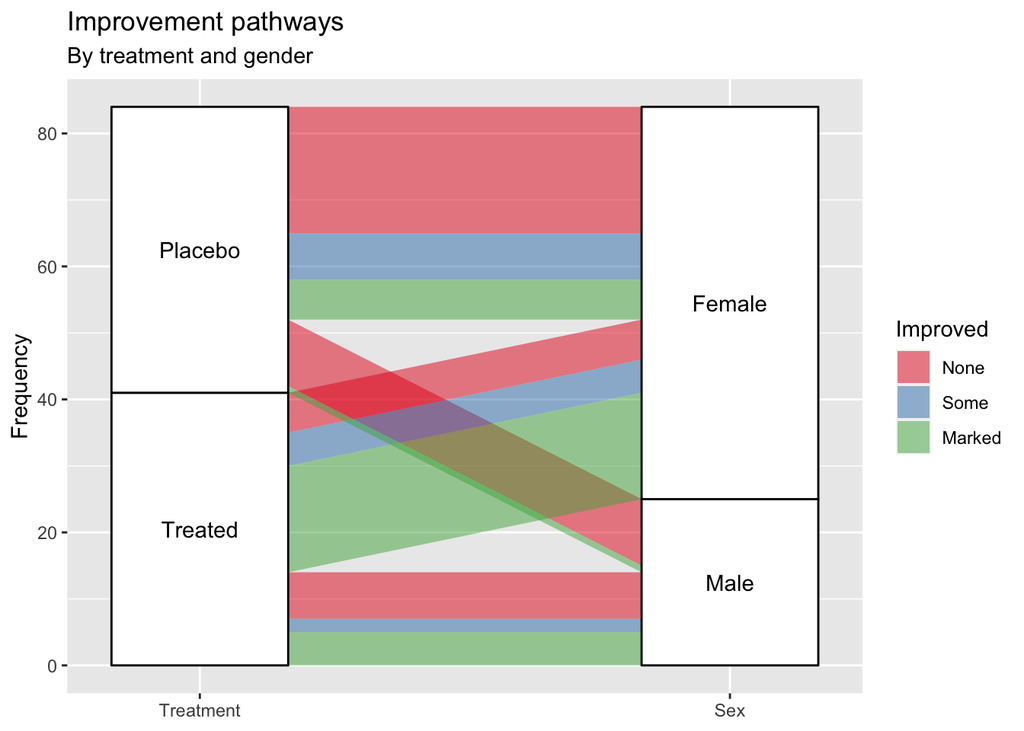

```r
Arthritis_grp %>%
ggplot(
  aes(y = n, axis1 = Treatment, axis2 = Sex)) +
  scale_x_discrete(limits = c("Treatment", "Sex"), expand = c(.2, .05)) +
  geom_alluvium(aes(fill = Improved), curve_type = "linear") +
  geom_stratum() +
  geom_text(stat = "stratum", aes(label = after_stat(stratum)), min.y = 5) +
  ggtitle("Improvement pathways",
          "By treatment and gender") +
  ylab("Frequency") +
  scale_fill_brewer(type = "qual", palette = "Set1")
```

### Cubic

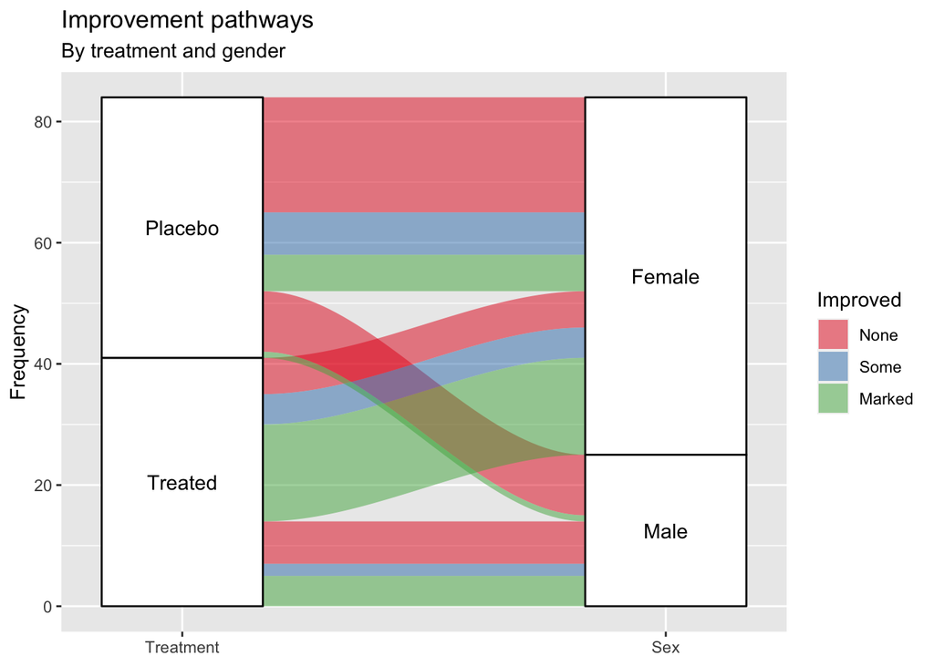

```r
Arthritis_grp %>%
ggplot(
  aes(y = n, axis1 = Treatment, axis2 = Sex)) +
  scale_x_discrete(limits = c("Treatment", "Sex"), expand = c(.2, .05)) +
  geom_alluvium(aes(fill = Improved), curve_type = "cubic") +
  geom_stratum() +
  geom_text(stat = "stratum", aes(label = after_stat(stratum)), min.y = 5) +
  ggtitle("Improvement pathways",
          "By treatment and gender") +
  ylab("Frequency") +
  scale_fill_brewer(type = "qual", palette = "Set1")
```

## Color

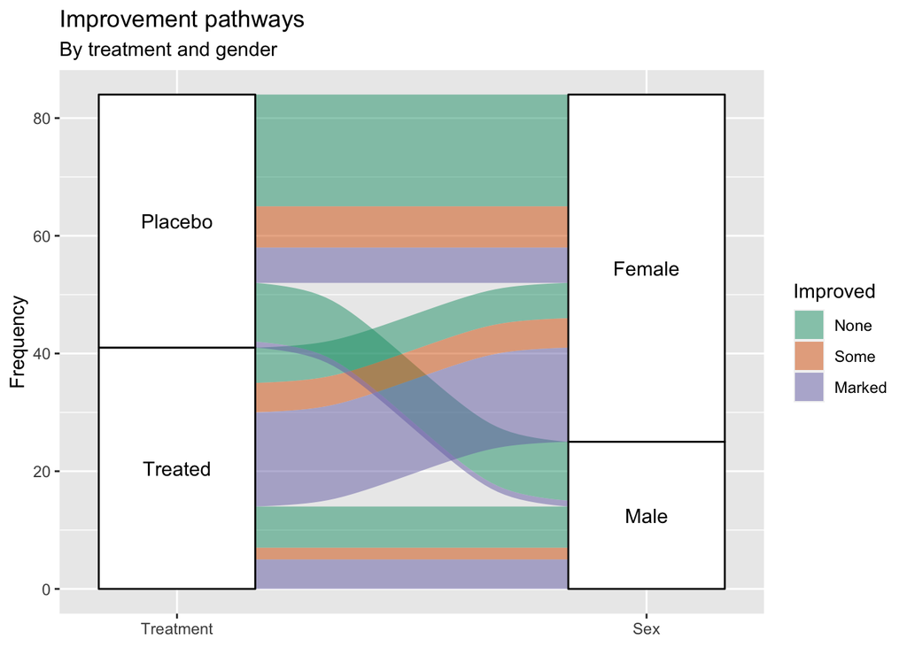

```r
Arthritis_grp %>%
ggplot(
  aes(y = n, axis1 = Treatment, axis2 = Sex)) +
  scale_x_discrete(limits = c("Treatment", "Sex"), expand = c(.2, .05)) +
  geom_alluvium(aes(fill = Improved)) +
  geom_stratum() +
  geom_text(stat = "stratum", aes(label = after_stat(stratum)), min.y = 5) +
  ggtitle("Improvement pathways",
          "By treatment and gender") +
  ylab("Frequency") +
  scale_fill_brewer(type = "qual", palette = "Dark2")
```

# Resources

https://cran.r-project.org/web/packages/ggalluvial/vignettes/ggalluvial.html

https://corybrunson.github.io/ggalluvial/

https://cran.r-project.org/web/packages/ggalluvial/ggalluvial.pdf

[figure not shown]

Division of Biostatistics

Department of Population Health Sciences

Victoria Cooley